# Evaluating Binary Classification Models

Ryan Miller

## Review

An effective model:

1. Accurately relates $\mathbf{X}$ and $Y$ (ie: achieves good prediction)
2. Helps the data analyst understand the relationship between $\mathbf{X}$ and $Y$ (ie: can be easily explained)

## Review

For numeric outcomes, “Good prediction” could be summarized using RMSE/MAE:

$$RMSE = \sqrt{\tfrac{1}{n}\sum_i (y_i - \hat{y}_i)^2} \qquad MAE = \tfrac{1}{n}\sum_i|y_i - \hat{y}_i|$$

- Overfitting refers to the tendency for a model to tailor itself too closely to the data it was trained on
- *In-sample* RMSE/MAE will *always* decrease as a model increases in complexity
- *Out-of-sample* RMSE/MAE provides a better assessment of how a model will generalize to new data

## Prediction and Binary Outcomes

For binary categorical outcomes, “Good prediction” is better measured using *accuracy*:

$$\text{Accuracy} = \frac{\text{Observations correctly classified}}{N}$$

- *In-sample* accuracy always improves as model complexity increases
- *Out-of-sample* accuracy provides a better assessment

## Class Imbalances

- Suppose we train a classification model to predict fraud using data on 100,000 transactions containing 100 known fraudulent transactions
- How do you feel about a model that achieves 99.9% out-of-sample classification accuracy?

## Class Imbalances

- A model that predicts every transaction is legitimate will correctly classify 99,900/100,000 = 99.9% of transactions!
  - But this model fails miserably in its actual goal of detecting/understanding fraud
- Instead we might want to measure how accurate our model is *beyond what we’d expect* from a naive model
  - Kappa is a tool for quantifying this:
    $$\kappa = \tfrac{p_o - p_e}{1 - p_e}$$
- $p_o$ is the observed accuracy and $p_e$ is the expected accuracy
- In the fraud example, $\kappa = (.999 - .999)/(1 - .999) = 0$

## Confusion Matrices

- As an alternative to Kappa, we may consider valuing certain types of misclassifications differently
- In general, misclassifications are summarized via the **confusion matrix**:

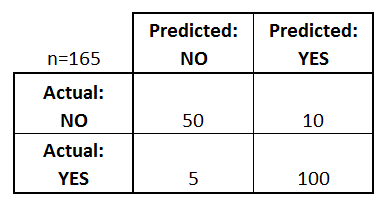

Image from https://www.dataschool.io/simple-guide-to-confusion-matrix-terminology/

## Sensitivity and Specificity

- **Sensitivity**, also known as the *true positive rate* or **Recall**:

$$\text{Sensitivity} = \frac{\text{True Positives}}{\text{True Positives + False Negatives}}$$

- **Specificity**, also known as the *true negative rate*:

$$\text{Specificity} = \frac{\text{True Negatives}}{\text{True Negatives + False Positives}}$$
In our fraud detection example:

- Sensitivity describes the fraction of *fraudulent transactions* that are classified as *fraud*
- Specificity describes the fraction of *legitimate transactions* that are classified as *legitimate*

## Sensitivity and Specificity

- It is common to use a *decision threshold* to adjust the sensitivity and specificity of a model:

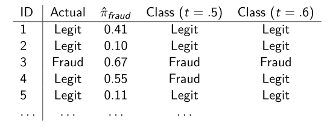

## ROC Curves

- It is easy to maximize either sensitivity or specificity if the other is ignored
  - Setting a decision threshold that classifies everything as fraud maximizes sensitivity (but specificity is 0)
  - Setting a decision threshold that classifies nothing as fraud maximizes specificity (but sensitivity is 0)
- This tradeoff is summarized using a Receiver Operating Characteristic Curve (ROC Curve)
  - The area under the ROC Curve (AUC) is used to summarize the curve
  - An AUC of 1 indicates perfect classification
  - An AUC of 0.5 is akin to randomly guessing

## ROC Curves

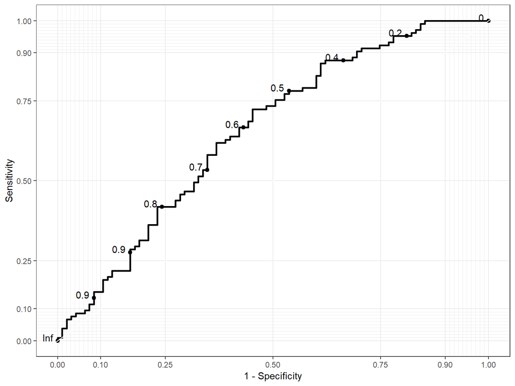

## Conclusion

- We’ve introduced several different measures for evaluating the performance of a classification model
  - **Accuracy** - Easy to understand and interpret
  - **Kappa** - Corrects for class imbalances, but has a less clear interpretation
  - **Sensitivity**/**Specificity** - Useful if certain types of misclassifications are more/less damaging
  - **AUC** - Useful for summarizing the trade-off between sensitivity/specificity and naturally accounting for class imbalances